# AssignmentCourse8

Saurabh Singh

7/5/2020

## Summary

This document is the final report of the peer assessment project from machine learning course, which is a part of data science specialization. The purpose of this analysis is to predict the manner in which the six participants performed the excercises described below and to answer the questions of associated course quiz. The machine leanring algorithm, which uses the classe variable in training set, is applied to the 20 test cases availabe in the test data.

## Introduction

Devices such as Jawbone Up, Nike FuelBand, and Fitbit can enable collecting a large amount of data about someone’s physical activity. These devices are used by the enthusiasts who take measurements about themselves regularly to improve their health, to find patterns in their behavior, or because they are tech geeks. However, even though these enthusiasts regularly quantify how much of a particular activity they do, they rarely quantify how well they do it. In this project, the goal is to use data from accelerometers on the belt, forearm, arm, and dumbell of six participants. They were asked to perform barbell lifts correctly and incorrectly in five different ways.

Load the training and test datasets

```r
data_train <- read.csv("pml-training.csv", na.strings = c("NA", ""))
data_quiz <- read.csv("pml-testing.csv", na.strings = c("NA", ""))
```

Create two partitions (75% and 25%) using the original training dataset

```r
in_train  <- createDataPartition(data_train$classe, p=0.75, list=FALSE)
train_set <- data_train[ in_train, ]
test_set  <- data_train[-in_train, ]
```

The two datasets (train_set and test_set) have a large number of NA values variables. columns with >20% NAs will be removed.

```r
missingFrac <- colSums(is.na(train_set))/dim(train_set)[1]
selectCols <- names(missingFrac)[missingFrac<.2]
train_set <- train_set[ , selectCols]
test_set  <- test_set [ , selectCols]
```

Columns with near zero variation will also be removed from both the train and the test datasets

```r
nzv_var <- nearZeroVar(train_set)
train_set <- train_set[ , -nzv_var]
test_set  <- test_set [ , -nzv_var]
```

It appears that columns 1 to 5 are just for identification. Therefore, these columns will also be removed

```r
train_set <- train_set[ , -(1:5)]
test_set  <- test_set [ , -(1:5)]
```

## Correlation Analysis

Correlation analysis is perromed to before the modeling work for exploratory data analysis purpose.

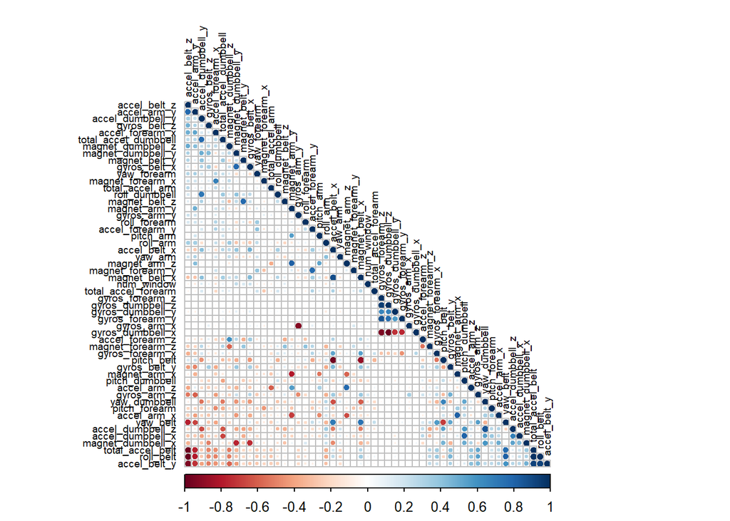

```r
corr_matrix <- cor(train_set[ , -54])
corrplot(corr_matrix, order = "FPC", method = "circle", type = "lower",
         tl.cex = 0.6, tl.col = rgb(0, 0, 0))
```

There are only a few variables, which exhibit very high correlations. Note that high correlation is indicated by dark blue or red colors. To reduce the number of variables principal componenet analysis (PCA) can be performed. However, there are only a few strong correlations among the input variables, we will not perform PCA.

## Prediction Models

### Linear Discriminant Analysis (LDA) Model

Train lda model on train_set, and predictions perfomed for test_set. Confusion matrix was then generated using test_set.

```r
set.seed(125)
modelFit_lda <- train(classe ~ ., method="lda", data=train_set)
pred_lda <- predict(modelFit_lda, newdata = test_set)
conf_matrix_lda <- confusionMatrix(pred_lda, test_set$classe)
conf_matrix_lda
```

```
## Confusion Matrix and Statistics
##
##           Reference
## Prediction    A    B    C    D    E
##          A 1148  130   78   47   37
##          B   34  607   81   22  149
##          C  101  119  564   90   81
##          D  105   40  104  615   82
##          E    7   53   28   30  552
##
## Overall Statistics
##
##                Accuracy : 0.7108
##                  95% CI : (0.6979, 0.7235)
##     No Information Rate : 0.2845
##     P-Value [Acc > NIR] : < 2.2e-16
##
##                   Kappa : 0.6342
##  Mcnemar's Test P-Value : < 2.2e-16
##
## Statistics by Class:
##
##                      Class: A Class: B Class: C Class: D Class: E
## Sensitivity            0.8229   0.6396   0.6596   0.7649   0.6127
## Specificity            0.9168   0.9277   0.9034   0.9193   0.9705
## Pos Pred Value         0.7972   0.6797   0.5906   0.6501   0.8239
## Neg Pred Value         0.9287   0.9147   0.9263   0.9522   0.9176
## Prevalence             0.2845   0.1935   0.1743   0.1639   0.1837
## Detection Rate         0.2341   0.1238   0.1150   0.1254   0.1126
## Detection Prevalence   0.2936   0.1821   0.1947   0.1929   0.1366
## Balanced Accuracy      0.8699   0.7837   0.7815   0.8421   0.7916
```

### Generalized Boosted Model (GBM)

```r
set.seed(125)
ctrl_GBM <- trainControl(method = "repeatedcv", number = 5, repeats = 2)
fit_GBM  <- train(classe ~ ., data = train_set, method = "gbm",
                  trControl = ctrl_GBM, verbose = FALSE)
fit_GBM$finalModel
```

```
## A gradient boosted model with multinomial loss function.
## 150 iterations were performed.
## There were 53 predictors of which 40 had non-zero influence.
```

Predictions on the GBM test_set.

```r
predict_GBM <- predict(fit_GBM, newdata = test_set)
conf_matrix_GBM <- confusionMatrix(predict_GBM, test_set$classe)
conf_matrix_GBM
```

```
## Confusion Matrix and Statistics
##
##           Reference
## Prediction    A    B    C    D    E
##          A 1382    9    0    0    0
##          B   11  929   13    1    4
##          C    0   11  838    9    2
##          D    0    0    4  794    8
##          E    2    0    0    0  887
##
## Overall Statistics
##
##                Accuracy : 0.9849
##                  95% CI : (0.9811, 0.9881)
##     No Information Rate : 0.2845
##     P-Value [Acc > NIR] : < 2.2e-16
##
##                   Kappa : 0.9809
##  Mcnemar's Test P-Value : NA
##
## Statistics by Class:
##
##                      Class: A Class: B Class: C Class: D Class: E
## Sensitivity            0.9907   0.9789   0.9801   0.9876   0.9845
## Specificity            0.9974   0.9927   0.9946   0.9971   0.9995
## Pos Pred Value         0.9935   0.9697   0.9744   0.9851   0.9978
## Neg Pred Value         0.9963   0.9949   0.9958   0.9976   0.9965
## Prevalence             0.2845   0.1935   0.1743   0.1639   0.1837
## Detection Rate         0.2818   0.1894   0.1709   0.1619   0.1809
## Detection Prevalence   0.2836   0.1954   0.1754   0.1644   0.1813
## Balanced Accuracy      0.9941   0.9858   0.9873   0.9923   0.9920
```

### Random Forest Model

```r
set.seed(125)
ctrl_RF <- trainControl(method = "repeatedcv", number = 5, repeats = 2)
fit_RF  <- train(classe ~ ., data = train_set, method = "rf",
                  trControl = ctrl_RF, verbose = FALSE)
fit_RF$finalModel
```

```
##
## Call:
##  randomForest(x = x, y = y, mtry = param$mtry, verbose = FALSE)
##                Type of random forest: classification
##                      Number of trees: 500
## No. of variables tried at each split: 27
##
##         OOB estimate of  error rate: 0.22%
## Confusion matrix:
##      A    B    C    D    E  class.error
## A 4184    0    0    0    1 0.0002389486
## B    5 2840    3    0    0 0.0028089888
## C    0    6 2560    1    0 0.0027269186
## D    0    0   12 2400    0 0.0049751244
## E    0    1    0    4 2701 0.0018477458
```

Predictions of the random forest model on test_set.

```r
predict_RF <- predict(fit_RF, newdata = test_set)
conf_matrix_RF <- confusionMatrix(predict_RF, test_set$classe)
conf_matrix_RF
```

```
## Confusion Matrix and Statistics
##
##           Reference
## Prediction    A    B    C    D    E
##          A 1394    0    0    0    0
##          B    1  948    1    0    0
##          C    0    0  854    4    0
##          D    0    1    0  799    0
##          E    0    0    0    1  901
##
## Overall Statistics
##
##                Accuracy : 0.9984
##                  95% CI : (0.9968, 0.9993)
##     No Information Rate : 0.2845
##     P-Value [Acc > NIR] : < 2.2e-16
##
##                   Kappa : 0.9979
##  Mcnemar's Test P-Value : NA
##
## Statistics by Class:
##
##                      Class: A Class: B Class: C Class: D Class: E
## Sensitivity            0.9993   0.9989   0.9988   0.9938   1.0000
## Specificity            1.0000   0.9995   0.9990   0.9998   0.9998
## Pos Pred Value         1.0000   0.9979   0.9953   0.9988   0.9989
## Neg Pred Value         0.9997   0.9997   0.9998   0.9988   1.0000
## Prevalence             0.2845   0.1935   0.1743   0.1639   0.1837
## Detection Rate         0.2843   0.1933   0.1741   0.1629   0.1837
## Detection Prevalence   0.2843   0.1937   0.1750   0.1631   0.1839
## Balanced Accuracy      0.9996   0.9992   0.9989   0.9968   0.9999
```

### Applying the best predictive model (i.e. Random Forest) to the Test Data

The Random Forest model is selected and applied to make predictions on the twenty data points from the original testing data set (data_quiz)

```r
predict_quiz <- predict(fit_RF, data_quiz)
predict_quiz
```

```
##  [1] B A B A A E D B A A B C B A E E A B B B
## Levels: A B C D E
```